# Hydrolytic Extracellular Enzyme Pre-test Calculations

Hava Blair

June 18, 2020

## Enzyme Pre-test Calculations

# Need to change mentions of “extinction” to “emission” ???

# Think about setting warnings for when # of standards is <4, and for when assay fluor exceeds max std fluor.

## Read in plate templates

Name your file with the ID of your plate. This will be added as its own column by plater so that you can identify which plate the data is coming from.

Files used with this version of the script should contain all the metadata in the csv file itself, in 4 blocks:

–“template” = standard, blank, and sample IDs. Empty wells (no sample, standard, or check) may be coded as “.”, “0” (zero), “NA”, or left blank.

–“Data” = raw fluorescence data from the plate reader

–“bad_wells” = identifies any wells that have known problems (ex. pipetting errors). May be coded as “bad”, “Bad”, “x”, or “X”. Anything with NA (blank) will be kept as “good”

–“ph_batch” has the pH of the buffer you used for this plate

The files you want to process must all be in a single folder, and that folder must not contain any other files R will attempt to read in all files in the designated folder.

Now you are ready to read in your files. If you get an error, check whether you have any extra CSV files in the designated folder.

```r
file.names <- dir("./plater-templates/")
file.paths<- paste0("./plater-templates/", file.names)
plates <- read_plates(file.paths)
colnames(plates) <- c("plate", "wells", "id", "fluor", "bad_wells", "ph_batch")
head(plates)
```

```
## # A tibble: 6 x 6
##   plate    wells id          fluor bad_wells ph_batch
##   <chr>    <chr> <chr>       <int> <chr>        <dbl>
## 1 1B-ST2-7 A01   B-Blank      2390 bad              7
## 2 1B-ST2-7 A02   B-Blank       408 <NA>             7
## 3 1B-ST2-7 A03   B-Blank       335 <NA>             7
## 4 1B-ST2-7 A04   B-Blank       344 <NA>             7
## 5 1B-ST2-7 A05   B-Assay-ST2  1933 <NA>             7
## 6 1B-ST2-7 A06   B-Assay-ST2  3365 <NA>             7
```

```r
unique(plates$plate) # To check that all plates read in correctly
```

```
## [1] "1B-ST2-7"   "3B-ST2-7"   "5B-ST2-5.6" "7B-ST2-5.6"
```

```r
nrow(plates)
```

```
## [1] 384
```

## Remove empty wells and known bad wells

```r
#Remove empty wells
no_missing <- subset(plates, !is.na(id) & id != 0 & id != ".")

# Remove bad wells and keep good ones
no_bad <- subset(no_missing, is.na(bad_wells))

#original PMN script has the code below to remove bad wells. Based on the way I have been filling out my templates, I think it can be sipmlified to subsetting based on "is.na(bad_wells)"
# plates <- subset(plates, Bad_wells != "bad" & Bad_wells != "Bad"
#                  & Bad_wells != "x" & Bad_wells != "X" | is.na(Bad_wells))

wells_removed <- nrow(plates) - nrow(no_bad)

glue("Removed {wells_removed} wells that were missing or bad")
```

```
## Removed 12 wells that were missing or bad
```

```r
clean_data <- no_bad
```

## Emission coefficient determination

```r
#Obtain the plate blank value by averaging the values in column 12 (id = Buf) of each plate

plate_blanks <- clean_data %>%
  select(plate, wells, id, fluor, ph_batch) %>%
  filter(id == "Buf") %>%
  group_by(plate) %>%
  summarise(plate_blnk_mean = mean(fluor), n = n())

# Average the MUB standard values (column 10) for each MUB concentration
mub_stds <- clean_data %>%
  select(plate, wells, id, fluor, ph_batch) %>%
  filter(str_detect(wells, "10")) %>%
  group_by(plate, id) %>%
  summarise(mub_std_mean = mean(fluor), n = n())

#Create a column for the plate blank values by joining the plate_blanks and mub_stds tbls
join_std_blnk <- left_join(plate_blanks, mub_stds, by = "plate")

#Subtract the plate blank from the fluorescence values for each averaged concentration
ext_coeff_tbl <- join_std_blnk %>%
  select(-n.x, -n.y) %>%
  mutate(corr_std_mean = mub_std_mean - plate_blnk_mean, mub_conc_uM = as.numeric(str_replace(join_std_blnk$id, "MUB", "")))
```

### Quench controls

```r
 #Obtain the plate blank + soil fluorescence value by averaging the values in column 11 (id = Buf+s) of each plate

plate_blnk_soil <- clean_data %>%
  select(plate, wells, id, fluor, ph_batch) %>%
  filter(id == "Buf+s") %>%
  group_by(plate) %>%
  summarise(plate_blnk_soil_mean = mean(fluor), n = n())

# Average the MUB+soil fluorescence values (column 9) for each MUB concentration
mub_soil_stds <- clean_data %>%
  select(plate, wells, id, fluor, ph_batch) %>%
  filter(str_detect(wells, "09")) %>%
  group_by(plate, id) %>%
  summarise(mub_soil_std_mean = mean(fluor), n = n())

#Create a column for the plate blank values by joining the plate_blanks and mub_stds tbls
join_soil_std_blnk <- left_join(plate_blnk_soil, mub_soil_stds, by = "plate")

join_soil_std_blnk
```

```
## # A tibble: 16 x 6
##    plate      plate_blnk_soil_mean   n.x id         mub_soil_std_mean   n.y
##    <chr>                     <dbl> <int> <chr>                  <dbl> <int>
##  1 1B-ST2-7                   76.4     8 MUB0.16+S               259      2
##  2 1B-ST2-7                   76.4     8 MUB0.625+S              648      2
##  3 1B-ST2-7                   76.4     8 MUB1.25+S              1106.     2
##  4 1B-ST2-7                   76.4     8 MUB2.5+S               2458.     2
##  5 3B-ST2-7                  109.      8 MUB0.16+S               242      2
##  6 3B-ST2-7                  109.      8 MUB0.625+S              643      2
##  7 3B-ST2-7                  109.      8 MUB1.25+S              1452.     2
##  8 3B-ST2-7                  109.      8 MUB2.5+S               3484      2
##  9 5B-ST2-5.6                 77.9     8 MUB0.16+S               156.     2
## 10 5B-ST2-5.6                 77.9     8 MUB0.625+S              273      2
## 11 5B-ST2-5.6                 77.9     8 MUB1.25+S               493      2
## 12 5B-ST2-5.6                 77.9     8 MUB2.5+S                632      1
## 13 7B-ST2-5.6                 66.8     8 MUB0.16+S               139      2
## 14 7B-ST2-5.6                 66.8     8 MUB0.625+S              386.     2
## 15 7B-ST2-5.6                 66.8     8 MUB1.25+S              1002      2
## 16 7B-ST2-5.6                 66.8     8 MUB2.5+S               1596.     2
```

```r
#Subtract the blank values from the fluorescence values for each averaged MUB concentration
quench_tbl <- join_soil_std_blnk %>%
  select(-n.x, -n.y) %>%
  mutate(corr_std_mean = mub_soil_std_mean - plate_blnk_soil_mean, mub_conc_uM = str_replace(join_soil_std_blnk$id, "MUB", ""))

quench_tbl$mub_conc_uM <- str_replace(quench_tbl$mub_conc_uM, "\\+", "")
quench_tbl$mub_conc_uM <- as.numeric(str_replace(quench_tbl$mub_conc_uM, "S", ""))
```

## Combine the emission and quench coefficient tables

```r
quench_select <- quench_tbl %>%
  select(plate, id, corr_std_mean, mub_conc_uM) %>%
  mutate(id = "quench")

ext_select <- ext_coeff_tbl %>%
  select(plate, id, corr_std_mean, mub_conc_uM) %>%
  mutate(id = "emission")

stds_for_lm <- rbind(quench_select, ext_select)

stds_list_cols <- stds_for_lm %>%
  group_by(plate, id) %>%
  nest()

lm_mod_ftn <- function(df){
  lm(corr_std_mean ~ mub_conc_uM, data = df)
}

m_stds_list <- stds_list_cols %>%
  mutate(model = map(data, lm_mod_ftn))

b_fun <- function(mod){
  coefficients(mod)[[1]]
}

slope_fun <- function(mod){
  coefficients(mod)[[2]]
}

r_sq_fun <- function(mod){
  summary(mod)[["r.squared"]]
}

max_fluor_fun <- function(data){
  max(data$corr_std_mean)
}

stds_coeffs <- m_stds_list %>%
  transmute(intcpt = map_dbl(model, b_fun), m_slope = map_dbl(model, slope_fun), r_squared = map_dbl(model, r_sq_fun), max_fluor = map_dbl(data, max_fluor_fun))

stds_coeffs
```

```
## # A tibble: 8 x 6
## # Groups:   plate, id [8]
##   plate      id        intcpt m_slope r_squared max_fluor
##   <chr>      <chr>      <dbl>   <dbl>     <dbl>     <dbl>
## 1 1B-ST2-7   quench    -25.4     941.     0.992     2381.
## 2 3B-ST2-7   quench   -257.     1414.     0.988     3375.
## 3 5B-ST2-5.6 quench     79.0     204.     0.934      554.
## 4 7B-ST2-5.6 quench     -7.40    636.     0.976     1529.
## 5 1B-ST2-7   emission -637.     5378.     0.991    13140.
## 6 3B-ST2-7   emission -563.     5085.     0.991    12477.
## 7 5B-ST2-5.6 emission  207.     3361.     0.993     8429
## 8 7B-ST2-5.6 emission  -21.1    3717.     0.998     9197.
```

# Plot emission curves

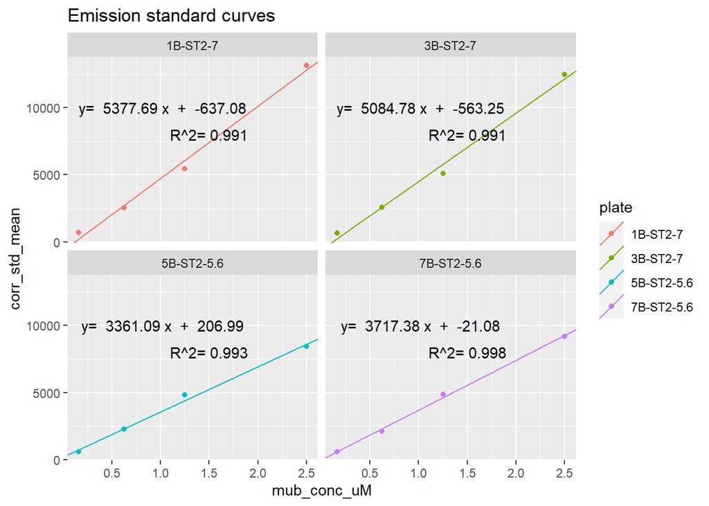

```r
emission_only <- subset(stds_coeffs, id == "emission")

ext_coeff_tbl %>%
  ggplot(aes(x = mub_conc_uM, y = corr_std_mean, color = plate)) +
  geom_point() +
  geom_abline(data = emission_only, aes(slope = m_slope, intercept = intcpt, color = plate)) +
  geom_text(data = emission_only, aes(x = 1.5, y = 8000,
                          label = paste("R^2=", round(r_squared, digits = 3))), inherit.aes = FALSE) +
  geom_text(data = emission_only, aes(x = 1.0, y = 10000,
                                    label = paste(" y= ", round(m_slope, digits = 2),
                                      "x", " + ", round(intcpt, digits = 2))), inherit.aes = FALSE) +
  facet_wrap(vars(plate)) +

labs(title = "Emission standard curves")
```

# Plot quench curves

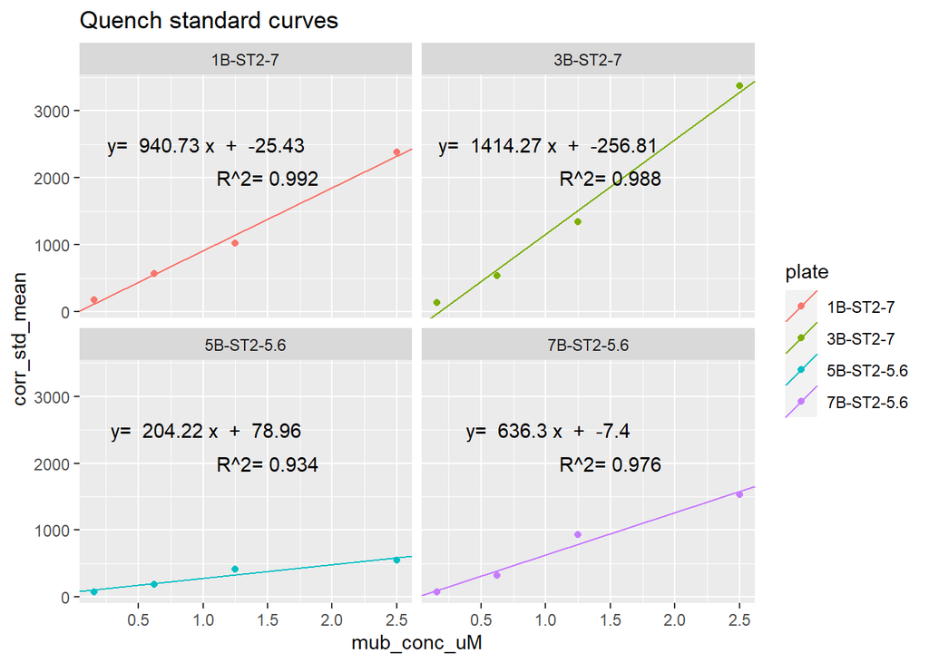

```r
quench_only <- subset(stds_coeffs, id == "quench")

quench_tbl %>%
  ggplot(aes(x = mub_conc_uM, y = corr_std_mean, color = plate)) +
  geom_point() +
  geom_abline(data = quench_only, aes(slope = m_slope, intercept = intcpt, color = plate)) +
  geom_text(data = quench_only, aes(x = 1.5, y = 2000,
                          label = paste("R^2=", round(r_squared, digits = 3))), inherit.aes = FALSE) +
  geom_text(data = quench_only, aes(x = 1.0, y = 2500,
                                    label = paste(" y= ", round(m_slope, digits = 2),
                                      "x", " + ", round(intcpt, digits = 2))), inherit.aes = FALSE) +
  facet_wrap(vars(plate)) +

labs(title = "Quench standard curves")
```

### Calculate extinction coefficient

The emission coefficient is the slope (m) from the emission standard curves you made above, divided by the assay volume

Pay attention to units! **slope (m) units** from the standard curves = fluor/uM = fluor/ (umol/L) = fluor L / umol = fluor mL / nmol

**assay volume** is 250uL = 0.00025 L = 0.250 mL

The protocol states: “Make sure this is calculated with the MUB concentrations in nmol/mL, which is equivalent to umol/L.”"

```r
assay_vol_ml <- 0.250

# emission coefficient units are fluorescence / nmol
calc_emission <-  emission_only %>%
  mutate(ext_coeff_fluor_per_nmol = m_slope/assay_vol_ml) %>%
  select(plate, max_fluor, ext_coeff_fluor_per_nmol, intcpt)
calc_emission
```

```
## # A tibble: 4 x 5
## # Groups:   plate, id [4]
##   id       plate      max_fluor ext_coeff_fluor_per_nmol intcpt
##   <chr>    <chr>          <dbl>                    <dbl>  <dbl>
## 1 emission 1B-ST2-7      13140.                   21511. -637.
## 2 emission 3B-ST2-7      12477.                   20339. -563.
## 3 emission 5B-ST2-5.6     8429                    13444.  207.
## 4 emission 7B-ST2-5.6     9197.                   14870.  -21.1
```

### Calculate the quench coefficient

```r
quench_coeff <- stds_coeffs %>%
  pivot_wider(id_cols = plate, names_from = id, names_prefix = "slope_", values_from = m_slope) %>%
  mutate(quench_coeff_no_unit = slope_quench/slope_emission)

quench_coeff
```

```
## # A tibble: 4 x 4
## # Groups:   plate [4]
##   plate      slope_quench slope_emission quench_coeff_no_unit
##   <chr>             <dbl>          <dbl>                <dbl>
## 1 1B-ST2-7           941.          5378.               0.175
## 2 3B-ST2-7          1414.          5085.               0.278
## 3 5B-ST2-5.6         204.          3361.               0.0608
## 4 7B-ST2-5.6         636.          3717.               0.171
```

```r
all_calcs <- cbind(quench_coeff, calc_emission) %>%
  select(-id, -plate1)

all_calcs
```

```
## # A tibble: 4 x 7
## # Groups:   plate [4]
##   plate slope_quench slope_emission quench_coeff_no~ max_fluor ext_coeff_fluor~
##   <chr>        <dbl>          <dbl>            <dbl>     <dbl>            <dbl>
## 1 1B-S~         941.          5378.           0.175     13140.           21511.
## 2 3B-S~        1414.          5085.           0.278     12477.           20339.
## 3 5B-S~         204.          3361.           0.0608     8429            13444.
## 4 7B-S~         636.          3717.           0.171      9197.           14870.
## # ... with 1 more variable: intcpt <dbl>
```

```r
#clean_data
```